# R Notebook

## Confidence-Slope plots

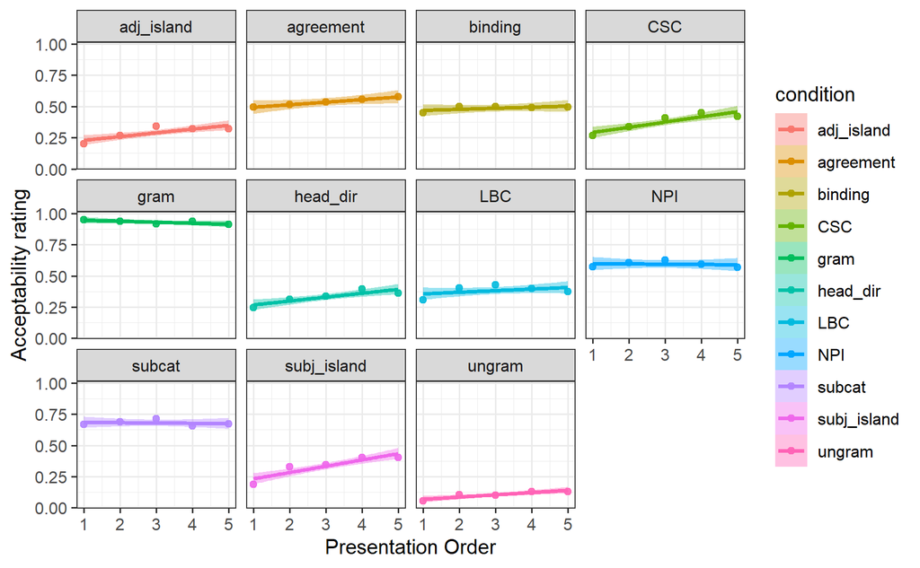

```r
combined_data = rbind.fill(data_no_practice1,data_no_practice2)
trial_means = combined_data %>%
  group_by(block_number,condition) %>%
  summarise(rating = mean(rating))
satiation_plot <- ggplot(combined_data, aes(x=block_number, y=rating, color = condition, fill = condition)) +
  geom_point(data=trial_means,alpha=.9) +
  # scale_color_manual(values=cbPalette) +
  #  scale_fill_manual(values=cbPalette) +
  xlab("Presentation Order") +
  ylab("Acceptability rating")+
  geom_smooth(method=lm, aes(fill=condition))+theme_bw()
#satiation_plot2

satiation_plot_faceted <- satiation_plot + facet_wrap(~condition, scales = "fixed")
satiation_plot_faceted
```

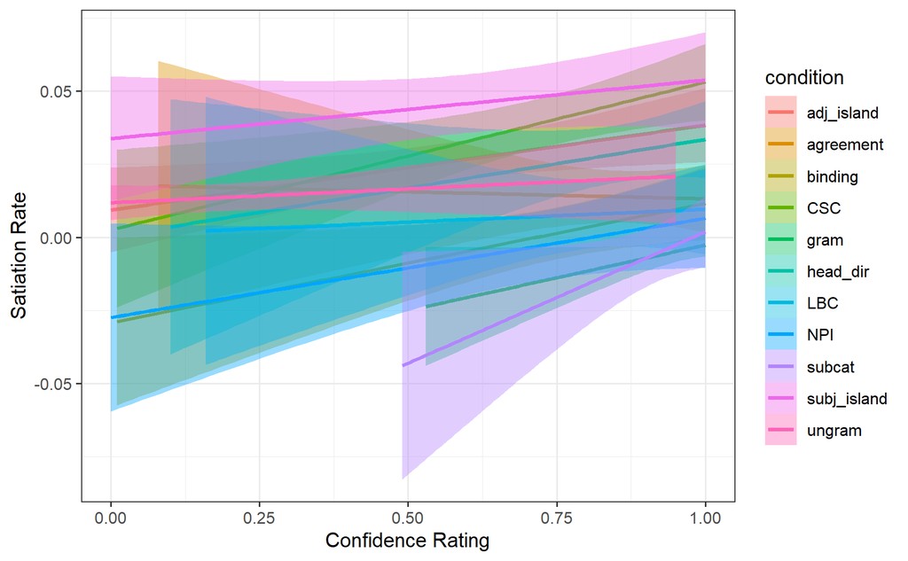

```r
slope_data1 = data_no_practice1 %>%
  group_by(workerid, condition)%>%
  do(tidy(lm(rating ~ block_number, data = .))) %>%
  filter(term == "block_number") %>%
  select(workerid, condition, estimate)
merged_data1 <- data_no_practice1 %>%
  left_join(slope_data1, by = c("workerid", "condition"))

merged1_trial_means= merged_data1 %>%
  group_by(workerid, condition)%>%
  summarise(estimate = mean(estimate), meaning_confidence = mean(meaning_confidence))
confidence_slope_plot1 <- ggplot(merged_data1, aes(x=meaning_confidence, y=estimate, color = condition, fill = condition)) +
#  geom_point(data=merged1_trial_means,alpha=.9) +
  # scale_color_manual(values=cbPalette) +
  #  scale_fill_manual(values=cbPalette) +
  xlab("Confidence Rating") +
  ylab("Satiation Rate")+
  geom_smooth(method=lm)+theme_bw()
confidence_slope_plot1
```

Now Let’s do the same for Group B:

```r
slope_data2 = data_no_practice2 %>%
  group_by(workerid, condition)%>%
  do(tidy(lm(rating ~ block_number, data = .))) %>%
  filter(term == "block_number") %>%
  select(workerid, condition, estimate)

merged_data2 <- data_no_practice2 %>%
  left_join(slope_data2, by = c("workerid", "condition"))

merged2_trial_means= merged_data2 %>%
  group_by(workerid, condition)%>%
  summarise(estimate = mean(estimate), meaning_confidence = mean(meaning_confidence))

confidence_slope_plot2 <- ggplot(merged_data2, aes(x=meaning_confidence, y=estimate, color = condition, fill = condition)) +
  #  geom_point(data=merged1_trial_means,alpha=.9) +
  # scale_color_manual(values=cbPalette) +
  #  scale_fill_manual(values=cbPalette) +
  xlab("Confidence Rating") +
  ylab("Satiation Rate")+
  geom_smooth(method=lm)+theme_bw()
confidence_slope_plot2
```

[output not shown]

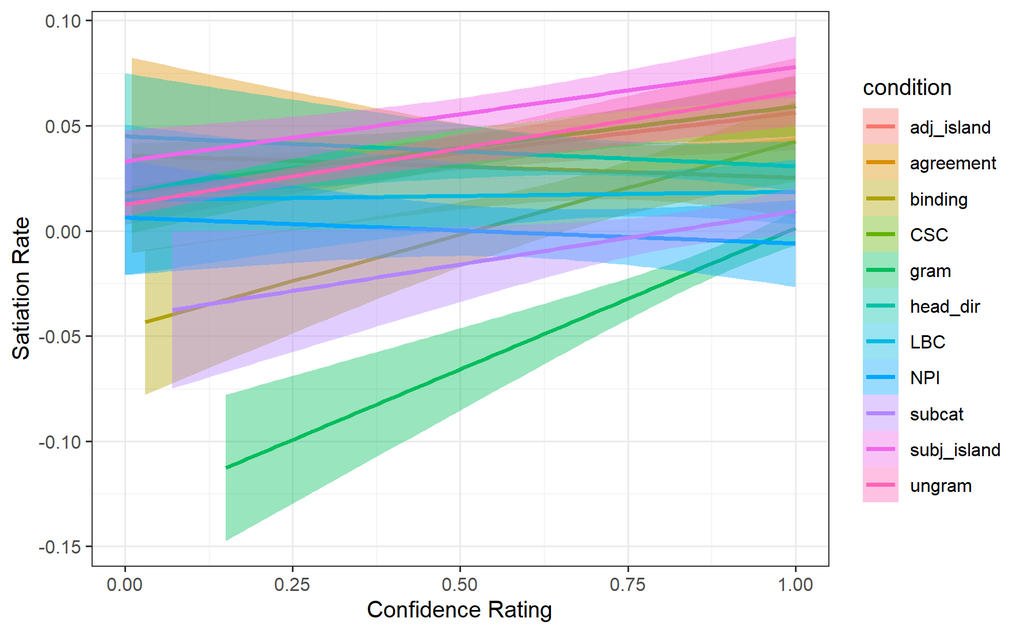

```r
slope_data2 = data_no_practice2 %>%
  group_by(workerid, condition)%>%
  do(tidy(lm(rating ~ block_number, data = .))) %>%
  filter(term == "block_number") %>%
  select(workerid, condition, estimate)
merged_data2 <- data_no_practice2 %>%
  left_join(slope_data2, by = c("workerid", "condition"))

merged2_trial_means= merged_data2 %>%
  group_by(workerid, condition)%>%
  summarise(estimate = mean(estimate), meaning_confidence = mean(meaning_confidence))
confidence_slope_plot2 <- ggplot(merged_data2, aes(x=meaning_confidence, y=estimate, color = condition, fill = condition)) +
  #  geom_point(data=merged1_trial_means,alpha=.9) +
  # scale_color_manual(values=cbPalette) +
  #  scale_fill_manual(values=cbPalette) +
  xlab("Confidence Rating") +
  ylab("Satiation Rate")+
  geom_smooth(method=lm)+theme_bw()
confidence_slope_plot2
```

Now, let’s combined the two groups:

```r
slope_data = combined_data %>%
  group_by(workerid, condition)%>%

  do(tidy(lm(rating ~ block_number, data = .))) %>%
  filter(term == "block_number") %>%
  select(workerid, condition, estimate)

merged_data <- combined_data %>%
  left_join(slope_data, by = c("workerid", "condition"))

merged_trial_means= merged_data %>%
  group_by(workerid, condition)%>%
  summarise(estimate = mean(estimate),meaning_confidence = mean(meaning_confidence))

confidence_slope_plot <- ggplot(merged_data, aes(x=meaning_confidence, y=estimate, color = condition, fill = condition)) +
#  geom_point(data=merged1_trial_means,alpha=.9) +
  # scale_color_manual(values=cbPalette) +
  #  scale_fill_manual(values=cbPalette) +
  xlab("Confidence Rating") +
  ylab("Satiation Rate")+
  geom_smooth(method=lm)+theme_bw()
confidence_slope_plot
```

[output not shown]

Here’s the faceted version of the combined plot:

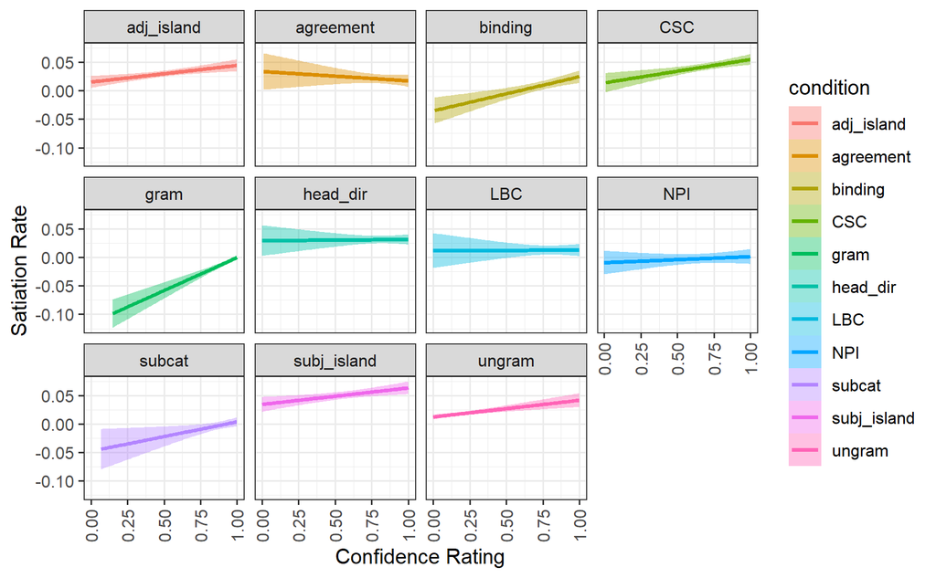

```r
confidence_slope_faceted <- confidence_slope_plot + facet_wrap(~condition, scales = "fixed")+theme(axis.text.x = element_text(angle = 90, vjust = 0.5, hjust=1))
confidence_slope_faceted
```

### Entropy Plots

The meaning types are labeled by hand. Let’s first plot Group A’s meaning entropy (Hm) for each participant-condition combination against the satiation rates:

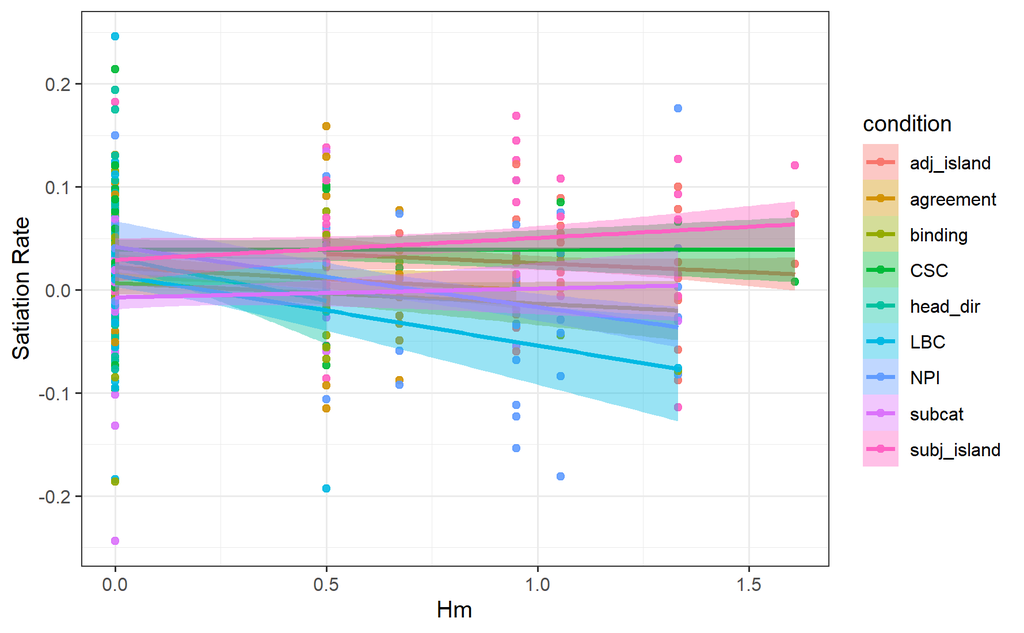

```r
data_no_fill1 <- subset(data_no_practice1, condition %notin% c("gram","ungram"))
entropy_results_1 <- data_no_fill1 %>%
  group_by(workerid, condition) %>%
  summarize(Hm = entropy(table(meaning_type)))
merged_data1_with_Hm <- merged_data1 %>%
  filter(condition %notin% c("gram","ungram"))%>%
  left_join(entropy_results_1, by = c("workerid", "condition"))


merged_Hm1_means= merged_data1_with_Hm %>%
  group_by(workerid, condition)%>%
  summarise(estimate = mean(estimate), Hm = mean(Hm))
Hm_plot_1 <- ggplot(merged_data1_with_Hm, aes(x=Hm, y=estimate, color = condition, fill = condition)) +
  geom_point(data=merged_Hm1_means,alpha=.9) +
  # scale_color_manual(values=cbPalette) +
  #  scale_fill_manual(values=cbPalette) +
  xlab("Hm") +
  ylab("Satiation Rate")+
  geom_smooth(method=lm)+theme_bw()
Hm_plot_1
```

Let’s facet the above plot by condition:

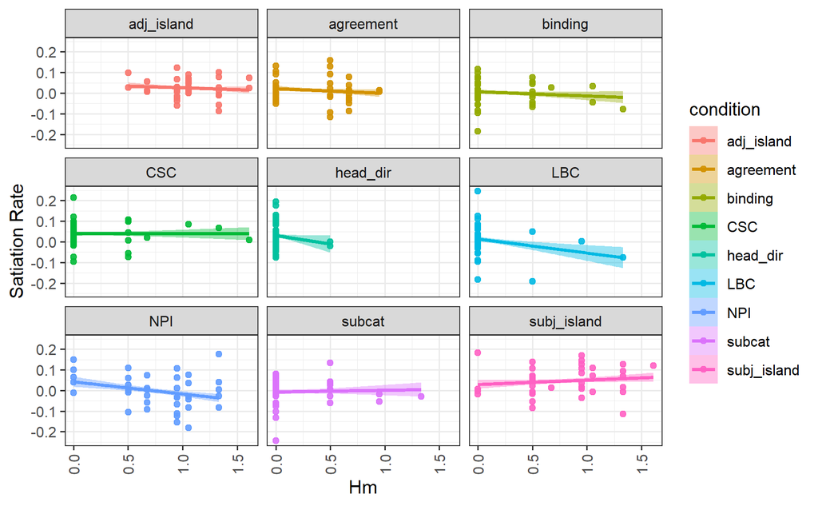

```r
Hm_plot_1_faceted <- Hm_plot_1 + facet_wrap(~condition, scales = "fixed")+theme(axis.text.x = element_text(angle = 90, vjust = 0.5, hjust=1))
Hm_plot_1_faceted
```

Turning to Group B, let’s create a entropy (for each condition-workerid pair) - satiation rate plot:

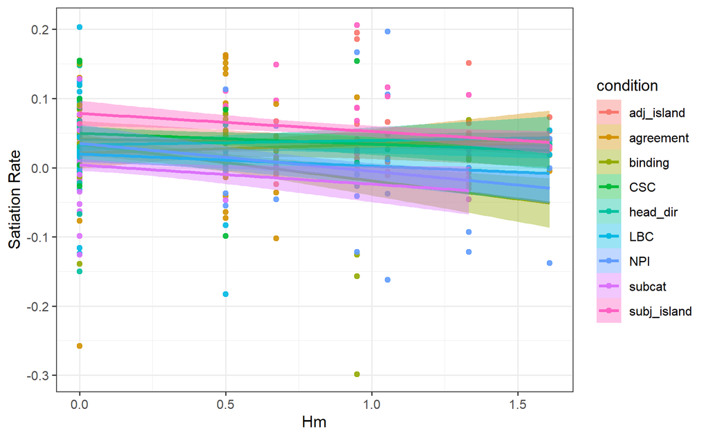

```r
data_no_fill2 <- subset(data_no_practice2, condition %notin% c("gram","ungram"))
entropy_results_2 <- data_no_fill2 %>%
  group_by(workerid, condition) %>%
  summarize(Hm = entropy(table(meaning_type)))
merged_data2_with_Hm <- merged_data2 %>%
  filter(condition %notin% c("gram","ungram"))%>%
  left_join(entropy_results_2, by = c("workerid", "condition"))


merged_Hm2_means= merged_data2_with_Hm %>%
  group_by(workerid, condition)%>%
  summarise(estimate = mean(estimate), Hm = mean(Hm))
Hm_plot_2 <- ggplot(merged_data2_with_Hm, aes(x=Hm, y=estimate, color = condition, fill = condition)) +
  geom_point(data=merged_Hm2_means,alpha=.9) +
  # scale_color_manual(values=cbPalette) +
  #  scale_fill_manual(values=cbPalette) +
  xlab("Hm") +
  ylab("Satiation Rate")+
  geom_smooth(method=lm)+theme_bw()
Hm_plot_2
```

This is too messy. Let’s facet by condition:

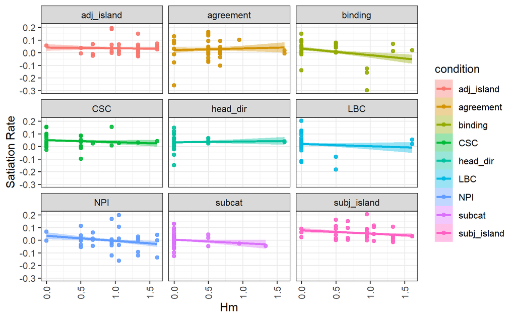

```r
Hm_plot_2_faceted <- Hm_plot_2 + facet_wrap(~condition, scales = "fixed")+theme(axis.text.x = element_text(angle = 90, vjust = 0.5, hjust=1))
Hm_plot_2_faceted
```

Collapsing the two groups:

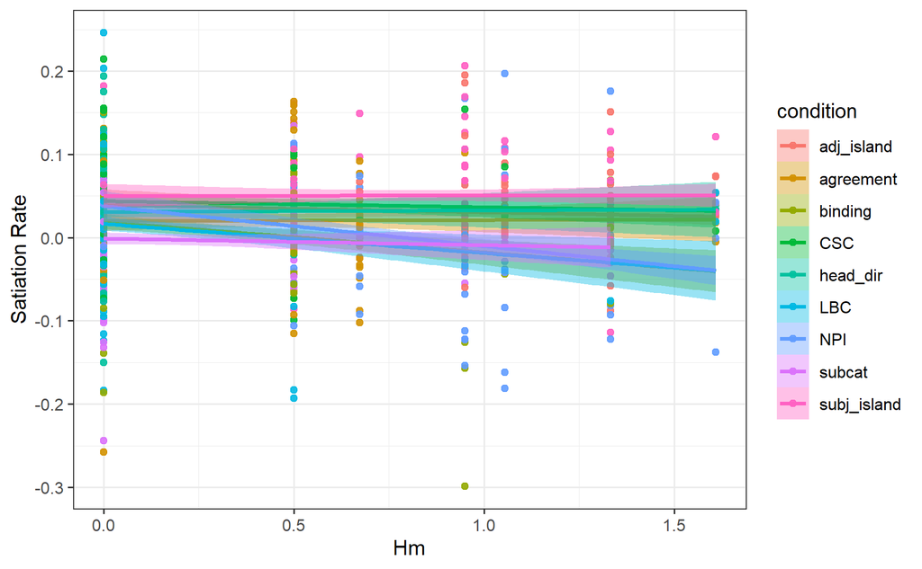

```r
merged_data_with_Hm <- rbind.fill(merged_data1_with_Hm,merged_data2_with_Hm)

merged_Hm_means= merged_data_with_Hm %>%
  group_by(workerid, condition)%>%
  summarise(estimate = mean(estimate), Hm = mean(Hm))
Hm_plot <- ggplot(merged_data_with_Hm, aes(x=Hm, y=estimate, color = condition, fill = condition)) +
  geom_point(data=merged_Hm_means,alpha=.9) +
  # scale_color_manual(values=cbPalette) +
  #  scale_fill_manual(values=cbPalette) +
  xlab("Hm") +
  ylab("Satiation Rate")+
  geom_smooth(method=lm)+theme_bw()
Hm_plot
```

Here’s the merged plot faceted by condition:

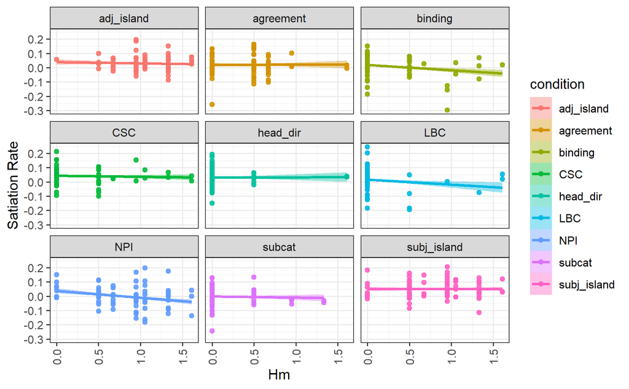

```r
Hm_plot_faceted <- Hm_plot + facet_wrap(~condition, scales = "fixed")+theme(axis.text.x = element_text(angle = 90, vjust = 0.5, hjust=1))
Hm_plot_faceted
```

# Analysis

Which conditions satiated?

```r
combined_data$condition <- factor(combined_data$condition)
combined_data$condition <- relevel(combined_data$condition, ref = "gram")


satiation_model <- lmer(rating ~ block_number*condition +
                          (1+block_number|workerid) , data = combined_data)
summary(satiation_model)
```

```
Linear mixed model fit by REML. t-tests use Satterthwaite's method ['lmerModLmerTest']
Formula: rating ~ block_number * condition + (1 + block_number | workerid)
   Data: combined_data

REML criterion at convergence: -1104.1

Scaled residuals:
    Min      1Q  Median      3Q     Max
-4.2303 -0.6622 -0.0711  0.6114  4.2103

Random effects:
 Groups   Name         Variance  Std.Dev. Corr
 workerid (Intercept)  0.0102457 0.10122
          block_number 0.0005282 0.02298  0.15
 Residual              0.0396899 0.19922
Number of obs: 3905, groups:  workerid, 71

Fixed effects:
                                    Estimate Std. Error         df t value Pr(>|t|)
(Intercept)                        9.544e-01  2.755e-02  8.786e+02  34.637  < 2e-16 ***
block_number                      -7.845e-03  7.959e-03  1.369e+03  -0.986 0.324443
conditionadj_island               -7.541e-01  3.507e-02  3.743e+03 -21.504  < 2e-16 ***
conditionagreement                -4.805e-01  3.507e-02  3.743e+03 -13.703  < 2e-16 ***
conditionbinding                  -4.929e-01  3.507e-02  3.743e+03 -14.056  < 2e-16 ***
conditionCSC                      -7.039e-01  3.507e-02  3.743e+03 -20.072  < 2e-16 ***
conditionhead_dir                 -7.169e-01  3.507e-02  3.743e+03 -20.442  < 2e-16 ***
conditionLBC                      -6.097e-01  3.507e-02  3.743e+03 -17.387  < 2e-16 ***
conditionNPI                      -3.530e-01  3.507e-02  3.743e+03 -10.065  < 2e-16 ***
conditionsubcat                   -2.667e-01  3.507e-02  3.743e+03  -7.606 3.54e-14 ***
conditionsubj_island              -7.720e-01  3.507e-02  3.743e+03 -22.014  < 2e-16 ***
conditionungram                   -9.035e-01  3.507e-02  3.743e+03 -25.763  < 2e-16 ***
block_number:conditionadj_island   3.765e-02  1.057e-02  3.743e+03   3.561 0.000375 ***
block_number:conditionagreement    2.839e-02  1.057e-02  3.743e+03   2.685 0.007277 **
block_number:conditionbinding      1.624e-02  1.057e-02  3.743e+03   1.536 0.124663
block_number:conditionCSC          4.966e-02  1.057e-02  3.743e+03   4.697 2.74e-06 ***
block_number:conditionhead_dir     3.901e-02  1.057e-02  3.743e+03   3.690 0.000228 ***
block_number:conditionLBC          2.056e-02  1.057e-02  3.743e+03   1.945 0.051877 .
block_number:conditionNPI          5.662e-03  1.057e-02  3.743e+03   0.535 0.592351
block_number:conditionsubcat       5.479e-03  1.057e-02  3.743e+03   0.518 0.604376
block_number:conditionsubj_island  5.837e-02  1.057e-02  3.743e+03   5.520 3.62e-08 ***
block_number:conditionungram       2.579e-02  1.057e-02  3.743e+03   2.439 0.014776 *
---
Signif. codes:  0 ‘***’ 0.001 ‘**’ 0.01 ‘*’ 0.05 ‘.’ 0.1 ‘ ’ 1
```

```
Correlation matrix not shown by default, as p = 22 > 12.
Use print(x, correlation=TRUE)  or
    vcov(x)        if you need it
```

Does confidence rating predict satiation rate?

```r
merged_trial_means$condition <- factor(merged_trial_means$condition)
merged_trial_means$condition <- relevel(merged_trial_means$condition, ref = "subj_island")



conf_model <- lmer(estimate ~ meaning_confidence*condition + (1+meaning_confidence|workerid) , data = merged_trial_means)
```

```
boundary (singular) fit: see ?isSingular
```

```r
summary(conf_model)
```

```
Linear mixed model fit by REML. t-tests use Satterthwaite's method ['lmerModLmerTest']
Formula: estimate ~ meaning_confidence * condition + (1 + meaning_confidence |      workerid)
   Data: merged_trial_means

REML criterion at convergence: -2065.5

Scaled residuals:
    Min      1Q  Median      3Q     Max
-4.1431 -0.4662 -0.0285  0.5374  3.8318

Random effects:
 Groups   Name               Variance  Std.Dev. Corr
 workerid (Intercept)        0.0001191 0.01091
          meaning_confidence 0.0002828 0.01682  1.00
 Residual                    0.0032814 0.05728
Number of obs: 781, groups:  workerid, 71

Fixed effects:
                                         Estimate Std. Error         df t value Pr(>|t|)
(Intercept)                              0.018287   0.019691 664.938708   0.929  0.35337
meaning_confidence                       0.057841   0.033574 725.050214   1.723  0.08535 .
conditionadj_island                     -0.022361   0.028513 698.651780  -0.784  0.43316
conditionagreement                       0.025510   0.047582 736.010082   0.536  0.59203
conditionbinding                        -0.094605   0.036674 716.277811  -2.580  0.01009 *
conditionCSC                            -0.021575   0.033075 707.807982  -0.652  0.51443
conditiongram                           -0.224655   0.075846 739.395228  -2.962  0.00315 **
conditionhead_dir                        0.009865   0.045152 731.264077   0.218  0.82711
conditionLBC                            -0.005897   0.045088 729.274190  -0.131  0.89598
conditionNPI                            -0.030805   0.031449 706.232704  -0.980  0.32765
conditionsubcat                         -0.105516   0.059269 738.920766  -1.780  0.07544 .
conditionungram                         -0.012690   0.022692 696.947564  -0.559  0.57618
meaning_confidence:conditionadj_island   0.009954   0.051795 702.476764   0.192  0.84765
meaning_confidence:conditionagreement   -0.086199   0.062096 733.237411  -1.388  0.16551
meaning_confidence:conditionbinding      0.057960   0.053238 717.108766   1.089  0.27665
meaning_confidence:conditionCSC          0.007863   0.050432 709.340754   0.156  0.87614
meaning_confidence:conditiongram         0.154897   0.084784 736.613608   1.827  0.06811 .
meaning_confidence:conditionhead_dir    -0.054125   0.059649 727.177739  -0.907  0.36450
meaning_confidence:conditionLBC         -0.057441   0.059999 724.920929  -0.957  0.33870
meaning_confidence:conditionNPI         -0.042335   0.049221 710.096582  -0.860  0.39003
meaning_confidence:conditionsubcat       0.038910   0.071302 734.580757   0.546  0.58543
meaning_confidence:conditionungram       0.007120   0.059831 690.475121   0.119  0.90531
---
Signif. codes:  0 ‘***’ 0.001 ‘**’ 0.01 ‘*’ 0.05 ‘.’ 0.1 ‘ ’ 1
```

```
Correlation matrix not shown by default, as p = 22 > 12.
Use print(x, correlation=TRUE)  or
    vcov(x)        if you need it
```

```
optimizer (nloptwrap) convergence code: 0 (OK)
boundary (singular) fit: see ?isSingular
```

Does entropy predict satiation rate?

```r
merged_Hm_means$condition <- factor(merged_Hm_means$condition)
merged_Hm_means$condition <- relevel(merged_Hm_means$condition, ref = "subj_island")

Hm_model <- lmer(estimate ~ Hm*condition + (1+Hm|workerid) , data = merged_Hm_means)
summary(Hm_model)
```

```
Linear mixed model fit by REML. t-tests use Satterthwaite's method ['lmerModLmerTest']
Formula: estimate ~ Hm * condition + (1 + Hm | workerid)
   Data: merged_Hm_means

REML criterion at convergence: -1591.5

Scaled residuals:
    Min      1Q  Median      3Q     Max
-3.8385 -0.4914 -0.0337  0.5459  3.4562

Random effects:
 Groups   Name        Variance  Std.Dev. Corr
 workerid (Intercept) 0.0011580 0.03403
          Hm          0.0003452 0.01858  -0.72
 Residual             0.0035682 0.05973
Number of obs: 639, groups:  workerid, 71

Fixed effects:
                         Estimate Std. Error         df t value Pr(>|t|)
(Intercept)              0.056197   0.016635 607.865780   3.378 0.000776 ***
Hm                      -0.006485   0.017773 551.760316  -0.365 0.715344
conditionadj_island     -0.013666   0.031095 571.948624  -0.439 0.660472
conditionagreement      -0.034206   0.019671 551.284774  -1.739 0.082620 .
conditionbinding        -0.038168   0.018342 559.097404  -2.081 0.037896 *
conditionCSC            -0.011158   0.018195 559.131208  -0.613 0.539955
conditionhead_dir       -0.024971   0.017757 560.019865  -1.406 0.160192
conditionLBC            -0.040258   0.017732 560.545658  -2.270 0.023567 *
conditionNPI            -0.027259   0.023320 565.832552  -1.169 0.242925
conditionsubcat         -0.055782   0.017948 559.784382  -3.108 0.001979 **
Hm:conditionadj_island  -0.005284   0.029465 572.210161  -0.179 0.857747
Hm:conditionagreement    0.003474   0.026977 565.169128   0.129 0.897574
Hm:conditionbinding     -0.027529   0.024951 569.754522  -1.103 0.270354
Hm:conditionCSC         -0.005069   0.024709 572.519572  -0.205 0.837542
Hm:conditionhead_dir     0.004242   0.030152 567.176472   0.141 0.888166
Hm:conditionLBC         -0.027869   0.027766 566.106049  -1.004 0.315938
Hm:conditionNPI         -0.032193   0.025390 577.040071  -1.268 0.205328
Hm:conditionsubcat      -0.009414   0.028594 573.421654  -0.329 0.742105
---
Signif. codes:  0 ‘***’ 0.001 ‘**’ 0.01 ‘*’ 0.05 ‘.’ 0.1 ‘ ’ 1
```

```
Correlation matrix not shown by default, as p = 18 > 12.
Use print(x, correlation=TRUE)  or
    vcov(x)        if you need it
```